# BayWheels System Data

#### by Nikolai Doinikov

- Preliminary Wrangling
- Univariate Exploration
  - Most Popular Stations
  - Trip Duration
  - Trip Timing
  - User Type
- Bivariate Exploration
  - Trip Duration vs. User Type
  - Geographical Clustering
- Multivariate Exploration
  - Trip Duration vs. Geographical Segment

## Preliminary Wrangling

The dataset represents all the bike trips in the database of the company BayWheels - which operates in the San Francisco Area, Oakland, Berkeley, and San José. This dataset does not require major cleaning and wrangling, except for a couple of datatype changes.

```python
# import all packages and set plots to be embedded inline
import numpy as np
import pandas as pd
import matplotlib.pyplot as plt
import seaborn as sb

%matplotlib inline
```

```python
df = pd.read_csv('ford.csv')
df.head()
```

|  | duration_sec | start_time | end_time | start_station_id | start_station_name | start_station_latitude | start_station_longitude | end_station_id | end_station_name | end_station_latitude | end_station_longitude | bike_id | user_type |
| --- | --- | --- | --- | --- | --- | --- | --- | --- | --- | --- | --- | --- | --- |
| 0 | 80110 | 2017-12-31 16:57:39.6540 | 2018-01-01 15:12:50.2450 | 74 | Laguna St at Hayes St | 37.776435 | -122.426244 | 43 | San Francisco Public Library (Grove St at Hyde... | 37.778768 | -122.415929 | 96 | Customer |
| 1 | 78800 | 2017-12-31 15:56:34.8420 | 2018-01-01 13:49:55.6170 | 284 | Yerba Buena Center for the Arts (Howard St at ... | 37.784872 | -122.400876 | 96 | Dolores St at 15th St | 37.766210 | -122.426614 | 88 | Customer |
| 2 | 45768 | 2017-12-31 22:45:48.4110 | 2018-01-01 11:28:36.8830 | 245 | Downtown Berkeley BART | 37.870348 | -122.267764 | 245 | Downtown Berkeley BART | 37.870348 | -122.267764 | 1094 | Customer |
| 3 | 62172 | 2017-12-31 17:31:10.6360 | 2018-01-01 10:47:23.5310 | 60 | 8th St at Ringold St | 37.774520 | -122.409449 | 5 | Powell St BART Station (Market St at 5th St) | 37.783899 | -122.408445 | 2831 | Customer |
| 4 | 43603 | 2017-12-31 14:23:14.0010 | 2018-01-01 02:29:57.5710 | 239 | Bancroft Way at Telegraph Ave | 37.868813 | -122.258764 | 247 | Fulton St at Bancroft Way | 37.867789 | -122.265896 | 3167 | Subscriber |

```python
# Perform the high-level observation of the dataset
df.info()
```

```
<class 'pandas.core.frame.DataFrame'>
RangeIndex: 519700 entries, 0 to 519699
Data columns (total 13 columns):
duration_sec               519700 non-null int64
start_time                 519700 non-null object
end_time                   519700 non-null object
start_station_id           519700 non-null int64
start_station_name         519700 non-null object
start_station_latitude     519700 non-null float64
start_station_longitude    519700 non-null float64
end_station_id             519700 non-null int64
end_station_name           519700 non-null object
end_station_latitude       519700 non-null float64
end_station_longitude      519700 non-null float64
bike_id                    519700 non-null int64
user_type                  519700 non-null object
dtypes: float64(4), int64(4), object(5)
memory usage: 51.5+ MB
```

```python
# Convert columns start_time and end_time to date format
df['start_time'] = pd.to_datetime(df['start_time'])
df['end_time'] = pd.to_datetime(df['end_time'])
```

```python
# Check if there are dupicated rows
sum(df.duplicated())
```

```
0
```

### What is the structure of your dataset?

There are 519700 different log of bike rides. Most variables are numeric in nature, but the variables `start_station_latitude`, `start_station_longitude`, `end_station_latitude`, `end_station_longitude`, should be (for now) considered categorical and nominal, since we cannot really perform any kind of mathematical operation with them.

### What is/are the main feature(s) of interest in your dataset?

The questions that are of the most interest to me are:

- What are the most popular stations to start a trip?
- How does the bike usage depend on the time of the day?

### What features in the dataset do you think will help support your investigation into your feature(s) of interest?

I expect that the trip duration and trip frequency depend very much on the time of the day, in particular on the common working hours.

## Univariate Exploration

### Most Popular Starting Stations

Let's take a look at the most popular stations in San Francisco Area.

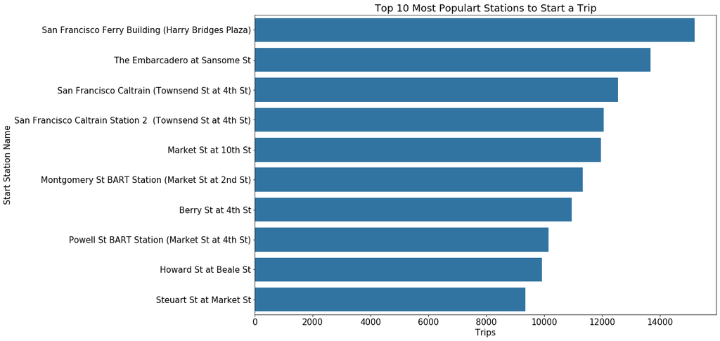

```python
# Filter and order 10 top start stations in the dataframe
order = df.start_station_name.value_counts().nlargest(10).index

# Set the base color
base_color = sb.color_palette()[0]

# Plot
plt.figure(figsize=[15,10])
sb.countplot(data = df, y = 'start_station_name', color = base_color, order = order)

# Polish ticks, labels, and title

plt.xlabel("Trips", size = 15)
plt.ylabel("Start Station Name", size = 15)
plt.title("Top 10 Most Populart Stations to Start a Trip", size = 18)
plt.xticks(size = 15)
plt.yticks(size = 15)

plt.show()
```

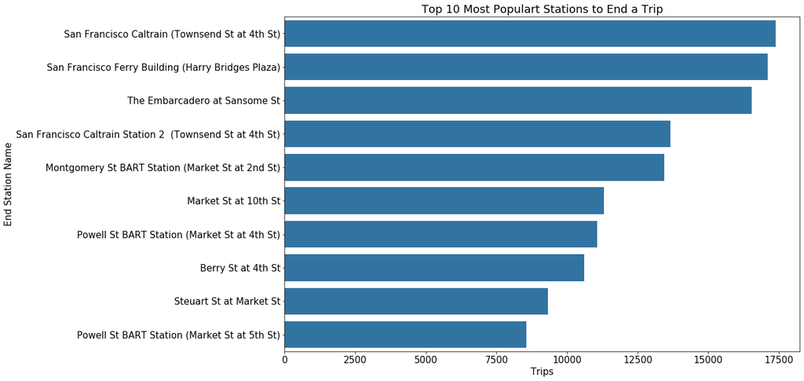

```python
# Filter and order 10 top start stations in the dataframe
order = df.end_station_name.value_counts().nlargest(10).index

# Set the base color
base_color = sb.color_palette()[0]

# Plot
plt.figure(figsize=[15,10])
sb.countplot(data = df, y = 'end_station_name', color = base_color, order = order)

# Polish ticks, labels, and title

plt.xlabel("Trips", size = 15)
plt.ylabel("End Station Name", size = 15)
plt.title("Top 10 Most Populart Stations to End a Trip", size = 18)
plt.xticks(size = 15)
plt.yticks(size = 15)

plt.show()
```

How do these these stations stand in terms of their share in the total pool of starting stations?

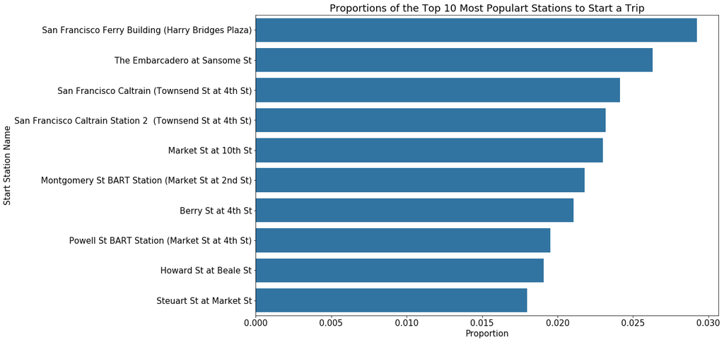

```python
# get proportion taken by most common group for derivation of tick marks
n_station = df.shape[0]
station_counts = df['start_station_name'].value_counts()
max_type_count = station_counts[0]
max_prop = max_type_count / n_station

# Generate tick mark location and names
tick_props = np.arange(0, max_prop+0.005, 0.005)
tick_names = ['{:0.3f}'.format(v) for v in tick_props]

# create the plot
plt.figure(figsize=[15,10])
base_color = sb.color_palette()[0]
order = df.start_station_name.value_counts().nlargest(10).index
sb.countplot(data = df, y = 'start_station_name', color = base_color, order = order)

# Polish ticks, labels, and title
plt.title("Proportions of the Top 10 Most Populart Stations to Start a Trip", size = 18)
plt.xticks(tick_props * n_station, tick_names, size=15)
plt.yticks(size = 15)
plt.xlabel('Proportion', size = 15)
plt.ylabel("Start Station Name", size = 15)

plt.show()
```

[figure not shown]

```python
# get proportion taken by most common group for derivation of tick marks
n_station = df.shape[0]
station_counts = df['end_station_name'].value_counts()
max_type_count = station_counts[0]
max_prop = max_type_count / n_station

# Generate tick mark location and names
tick_props = np.arange(0, max_prop+0.005, 0.005)
tick_names = ['{:0.3f}'.format(v) for v in tick_props]

# create the plot
plt.figure(figsize=[15,10])
base_color = sb.color_palette()[0]
order = df.end_station_name.value_counts().nlargest(10).index
sb.countplot(data = df, y = 'end_station_name', color = base_color, order = order)

# Polish ticks, labels, and title
plt.title("Proportions of the Top 10 Most Populart Stations to End a Trip", size = 18)
plt.xticks(tick_props * n_station, tick_names, size=15)
plt.yticks(size = 15)
plt.xlabel('Proportion', size = 15)
plt.ylabel("End Station Name", size = 15)

plt.show()
```

As we can see here, the top 10 start stations have popularity proportions ranging from around 1,75% to 3%.

### Trip Duration

Are there any interesting observation about the distribution of trips' duration?

```python
df.duration_sec.describe()
```

```
count    519700.000000
mean       1099.009521
std        3444.146451
min          61.000000
25%         382.000000
50%         596.000000
75%         938.000000
max       86369.000000
Name: duration_sec, dtype: float64
```

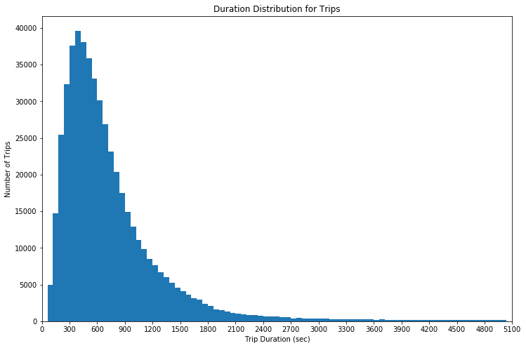

```python
plt.figure(figsize=[12,8])

bin_size = 60
ticks = np.arange(0,5000+300,300)
bins = np.arange(0,5000+bin_size,bin_size)
plt.hist(data = df, x='duration_sec', bins = bins)
plt.xlim(0,5100)

# Polish ticks, labels, and title
plt.xticks(ticks = ticks)
plt.xlabel("Trip Duration (sec)")
plt.ylabel("Number of Trips")
plt.title("Duration Distribution for Trips")

plt.show()
```

The distribution of the trip duration is visibly skewed to the right: there are many short trips and very few long trips. In order to test the distribution further, I will use the logarithmic scale for the above distribution.

```python
np.log10(df.duration_sec.describe())
```

```
count    5.715753
mean     3.041001
std      3.537082
min      1.785330
25%      2.582063
50%      2.775246
75%      2.972203
max      4.936358
Name: duration_sec, dtype: float64
```

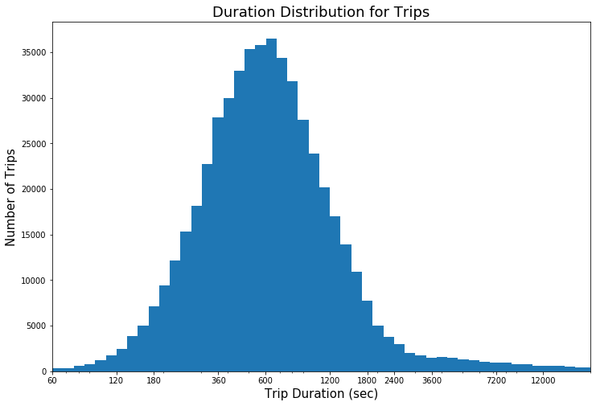

```python
plt.figure(figsize=[12,8])

bin_edges = 10 ** np.arange(1.78, 4.93+0.05, 0.05)
ticks = [60, 120, 180, 360, 600, 1200, 1800, 2400, 3600, 7200, 12000]
labels = ['{}'.format(v) for v in ticks]
plt.hist(data = df, x = 'duration_sec', bins = bin_edges)
plt.xscale('log')
plt.xlim(60,20000)


# Polish ticks, labels, and title
plt.xticks(ticks,labels)
plt.xlabel("Trip Duration (sec)", size = 15)
plt.ylabel("Number of Trips", size = 15)
plt.title("Duration Distribution for Trips", size = 18)

plt.show()
```

Using the logarithmic scale, we can clearly see that the distribution of trip duration is unimodal and peaks at around 600 seconds (10 minutes). The majority of observations are captured somewhere around 180 seconds (3 minutes) and 1800 seconds (30 minutes).

### Trip Timing

I will try now to depict any trends related to the timing of trips. I will analyse the hours when bikes were taken and also when they were put back.

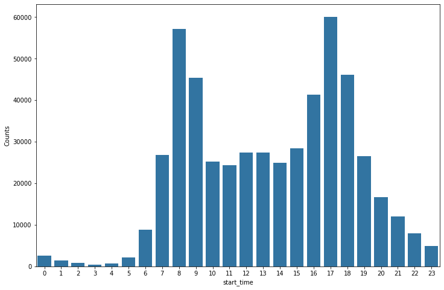

```python
# Plot the barplot for when the trips usually start
plt.figure(figsize=[12,8])
start_hour = df.groupby(df['start_time'].dt.hour).size().reset_index(name='Counts')
sb.barplot(data = start_hour, x = 'start_time', y = 'Counts', color = base_color)

plt.show()
```

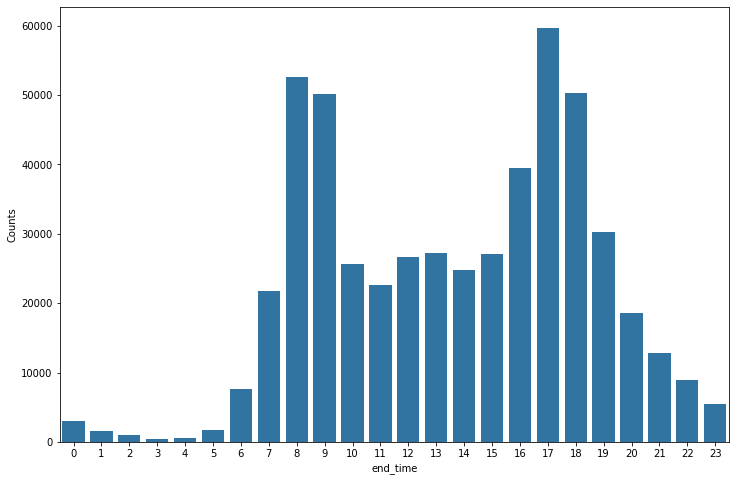

```python
# Plot the barplot for when the trips usually end
plt.figure(figsize=[12,8])
end_hour = df.groupby(df['end_time'].dt.hour).size().reset_index(name='Counts')
sb.barplot(data = end_hour, x = 'end_time', y = 'Counts', color = base_color)

plt.show()
```

How do start and end hours stand with each other?

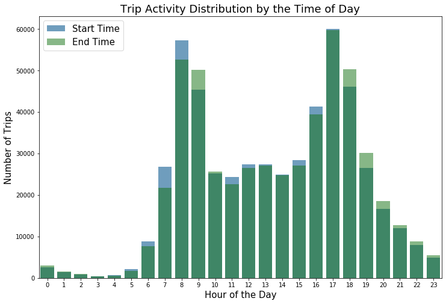

```python
# Plot the barplot for when the trips usually start
plt.figure(figsize=[12,8])

start_hour = df.groupby(df['start_time'].dt.hour).size().reset_index(name='Counts')
sb.barplot(data = start_hour, x = 'start_time', y = 'Counts', color = base_color, alpha=0.7, label='Start Time')

end_hour = df.groupby(df['end_time'].dt.hour).size().reset_index(name='Counts')
sb.barplot(data = end_hour, x = 'end_time', y = 'Counts', color = 'green', alpha=0.5, label='End Time')

# Polish labels, legend, and title
plt.xlabel("Hour of the Day", size = 15)
plt.ylabel("Number of Trips", size = 15)
plt.title("Trip Activity Distribution by the Time of Day", size = 18)
plt.legend(loc = 'upper left', fontsize = 15)

plt.show()
```

### User Type

The third interesting variable is type of users. Since we only have two of them, let's explore the question: what is the actual split for trips by the user type?

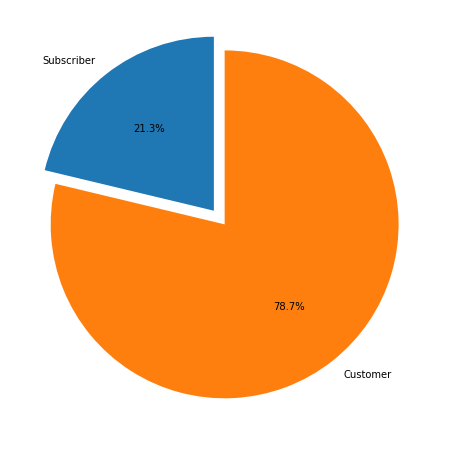

```python
plt.figure(figsize=[12,8])

# Plot for User Type
user = df.groupby('user_type').size().reset_index(name='counts')
labels = user['user_type'].value_counts().index
plt.pie(data = user, x = 'counts', startangle = 90, labels = labels, autopct='%1.1f%%', explode = [0.1,0])

plt.show()
```

### Discuss the distribution(s) of your variable(s) of interest. Were there any unusual points? Did you need to perform any transformations?

The `duration_sec` variable took on a large range of values with some radical outliers, so I looked at the data using a log transform. Under the transformation, the data looked unimodal, with one peak around *600* seconds (10 minutes).

### Of the features you investigated, were there any unusual distributions? Did you perform any operations on the data to tidy, adjust, or change the form of the data? If so, why did you do this?

Iа we discuss further the outliers for `duration_sec` variable, they do not seem sur-real, but more likely to be really rare and quite exceptional in nature. One bike was rented for **80,000** seconds (more than 22 hours!), so I can only guess that it was either a technical issue or someone just forgot to bring it back.

## Bivariate Exploration

### Trip Duration vs. User Type

Questions: are there any differences in trip duration dynamics between two groups of user types: subscribers and customers?

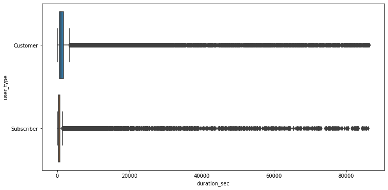

```python
# Plot a box plot
plt.figure(figsize=[12,6])
sb.boxplot(data = df, y = 'user_type', x = 'duration_sec')

plt.show()
```

Clearly, the same issue with `duration_sec` outliers prevent us from having a meaningful visualization. Therefore, let's use the logarithmic scale once again.

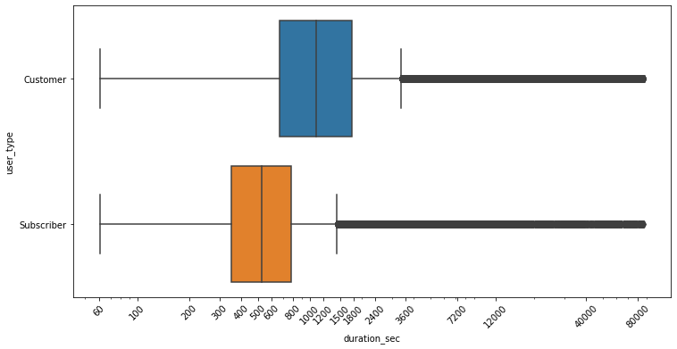

```python
# Plot a box plot
plt.figure(figsize=[12,6])
sb.boxplot(data = df, y = 'user_type', x = 'duration_sec')

# Polish ticks and scales
ticks = [60, 100, 200, 300, 400, 500, 600, 800, 1000, 1200, 1500, 1800, 2400, 3600, 7200, 12000, 40000, 80000]
labels = ['{}'.format(v) for v in ticks]
plt.xscale('log')
plt.xticks(ticks, labels, rotation = 45)

plt.show()
```

### Geographical Clustering

At first, I was not planning to analyse the geographical columns (latitudes, longitudes), but decided to give it a try.

The question is: are there any interesting observations in terms of GPS?

```python
print(df.start_station_latitude.describe())
print(df.start_station_longitude.describe())
```

```
count    519700.000000
mean         37.771653
std           0.086305
min          37.317298
25%          37.773492
50%          37.783521
75%          37.795392
max          37.880222
Name: start_station_latitude, dtype: float64
count    519700.000000
mean       -122.363927
std           0.105573
min        -122.444293
25%        -122.411726
50%        -122.398870
75%        -122.391034
max        -121.874119
Name: start_station_longitude, dtype: float64
```

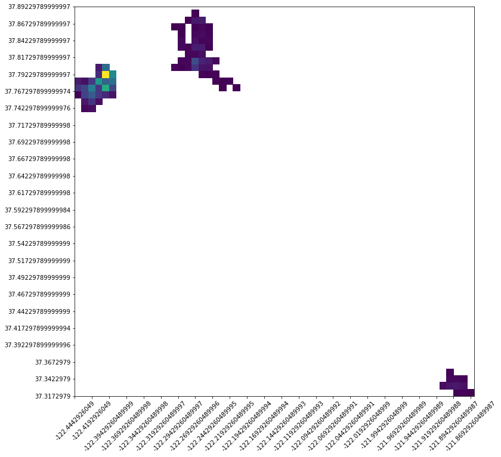

```python
plt.figure(figsize=[12,12])

bins_x = np.arange(df.start_station_longitude.min(), df.start_station_longitude.max()+0.01, 0.01)
ticks_x = np.arange(df.start_station_longitude.min(), df.start_station_longitude.max()+0.025, 0.025)
bins_y = np.arange(df.start_station_latitude.min(), df.start_station_latitude.max()+0.01, 0.01)
ticks_y = np.arange(df.start_station_latitude.min(), df.start_station_latitude.max()+0.025, 0.025)

plt.hist2d(data = df, x = 'start_station_longitude', y = 'start_station_latitude', cmin = 0.5,
          bins = [bins_x, bins_y])
plt.xticks(ticks = ticks_x, labels = ticks_x, rotation = 45)
plt.yticks(ticks = ticks_y, labels = ticks_y)

plt.show()
```

This heatmap confirms the geographical clustering for the bikeshare system: there are three major clusters in the San Francisco Area. I took the middle points of each heatmap and put them into a search engine:

- Cluster 1 - San José (37.320000, -121.890000)
- Cluster 2 - Oakland / Berkeley (37.78000, -122.27000)
- Cluster 3 - San Francisco (37.76000, -122.40000)

This assumption about 3 clusters is confirmed by the BayWheels [internet site](https://member.baywheels.com/map/).

### Talk about some of the relationships you observed in this part of the investigation. How did the feature(s) of interest vary with other features in the dataset?

There are clearly some observable differences between two groups of users: customers and subscribers. Customers tend to have longer trip durations than subscribers.

### Did you observe any interesting relationships between the other features (not the main feature(s) of interest)?

At first, I did not plan to analyze latitudes and longitudes, but thanks to `pyplot`'s heatmap functionality I managed to discover 3 geographical clusters, where we could perform multivariate analysis later on.

## Multivariate Exploration

### Trip Duration vs. Geographical Segment

```python
# Separate the biggest cluster - San Francisco - from other segments

df_sf = df[df['start_station_latitude'] > 37.7]
df_sf = df_sf[df_sf['start_station_longitude'] < (-122.37)]
df_sf = df_sf[df_sf['end_station_latitude'] > 37.7]
df_sf = df_sf[df_sf['end_station_longitude'] < (-122.37)]
```

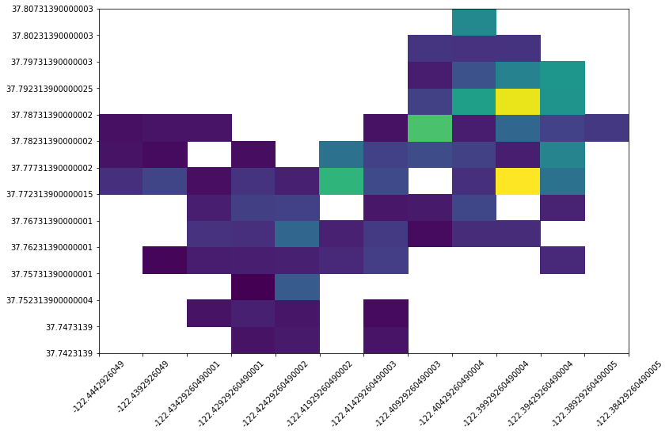

```python
# Check that we have only the San Francisco cluster in Start section and draw a heatmap
plt.figure(figsize=[12,8])

bins_x = np.arange(df_sf.start_station_longitude.min(), df_sf.start_station_longitude.max()+0.005, 0.005)
ticks_x = np.arange(df_sf.start_station_longitude.min(), df_sf.start_station_longitude.max()+0.005, 0.005)
bins_y = np.arange(df_sf.start_station_latitude.min(), df_sf.start_station_latitude.max()+0.005, 0.005)
ticks_y = np.arange(df_sf.start_station_latitude.min(), df_sf.start_station_latitude.max()+0.005, 0.005)

plt.hist2d(data = df_sf, x = 'start_station_longitude', y = 'start_station_latitude', cmin = 0.5,
          bins = [bins_x, bins_y])
plt.xticks(ticks = ticks_x, labels = ticks_x, rotation = 45)
plt.yticks(ticks = ticks_y, labels = ticks_y)

plt.show()
```

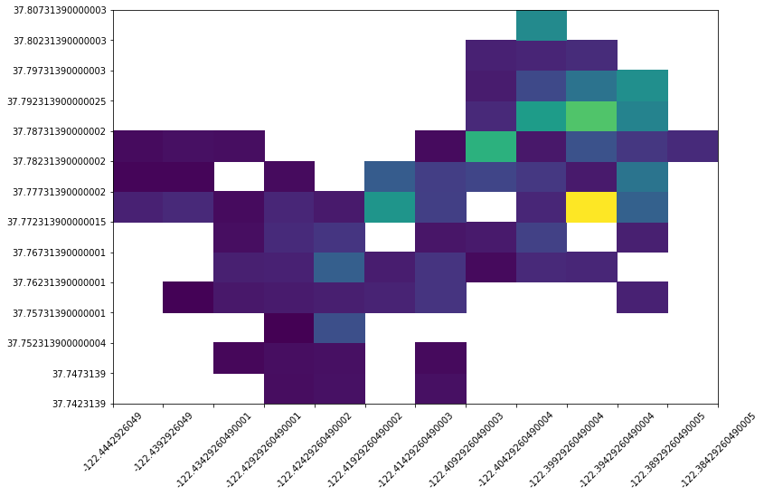

```python
# Check that we have only the San Francisco cluster in End section and draw a heatmap
plt.figure(figsize=[12,8])

bins_x = np.arange(df_sf.end_station_longitude.min(), df_sf.end_station_longitude.max()+0.005, 0.005)
ticks_x = np.arange(df_sf.end_station_longitude.min(), df_sf.end_station_longitude.max()+0.005, 0.005)
bins_y = np.arange(df_sf.end_station_latitude.min(), df_sf.end_station_latitude.max()+0.005, 0.005)
ticks_y = np.arange(df_sf.end_station_latitude.min(), df_sf.end_station_latitude.max()+0.005, 0.005)

plt.hist2d(data = df_sf, x = 'end_station_longitude', y = 'end_station_latitude', cmin = 0.5,
          bins = [bins_x, bins_y])
plt.xticks(ticks = ticks_x, labels = ticks_x, rotation = 45)
plt.yticks(ticks = ticks_y, labels = ticks_y)

plt.show()
```

```python
# Round GPS coordinates down to 2 signs - to get a clearer geographical grid
df_sf['start_station_latitude'] = round(df_sf['start_station_latitude'],2)
df_sf['start_station_longitude'] = round(df_sf['start_station_longitude'],2)
df_sf['end_station_latitude'] = round(df_sf['end_station_latitude'],2)
df_sf['end_station_longitude'] = round(df_sf['end_station_longitude'],2)
```

```python
# Calculate the duration mean
duration_mean = df_sf.duration_sec.mean()
duration_mean
```

```
1084.405813204313
```

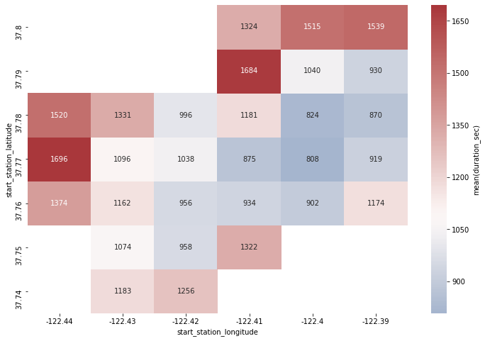

```python
# Plot the mean duration of a trip per GPS segment of the starting location
plt.figure(figsize=[12,8])

gps_means_start = df_sf.groupby(['start_station_latitude', 'start_station_longitude']).mean()['duration_sec']
gps_means_start = gps_means_start.reset_index(name = 'duration_avg')
gps_means_start = gps_means_start.pivot(index = 'start_station_latitude', columns = 'start_station_longitude',
                            values = 'duration_avg')

ax = sb.heatmap(gps_means_start, annot = True, fmt = '.0f',
           cbar_kws = {'label' : 'mean(duration_sec)'}, center = duration_mean, cmap = 'vlag')

# Prevent top and bottom boxes from being cut off
bottom, top = ax.get_ylim()
ax.set_ylim(bottom + 0.5, top - 0.5)

# reverse y-axis
ax.invert_yaxis()
```

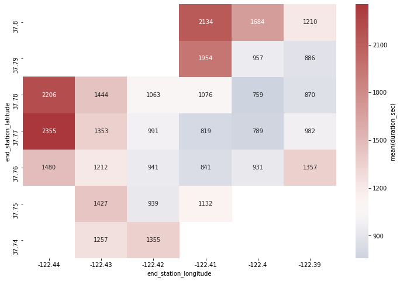

```python
# Plot the mean duration of a trip per GPS segment of the ending location
plt.figure(figsize=[12,8])

gps_means_end = df_sf.groupby(['end_station_latitude', 'end_station_longitude']).mean()['duration_sec']
gps_means_end = gps_means_end.reset_index(name = 'duration_avg')
gps_means_end = gps_means_end.pivot(index = 'end_station_latitude', columns = 'end_station_longitude',
                            values = 'duration_avg')

ax = sb.heatmap(gps_means_end, annot = True, fmt = '.0f',
           cbar_kws = {'label' : 'mean(duration_sec)'}, center = duration_mean, cmap = 'vlag')

# Prevent top and bottom boxes from being cut off
bottom, top = ax.get_ylim()
ax.set_ylim(bottom + 0.5, top - 0.5)

# reverse y-axis
ax.invert_yaxis()
```

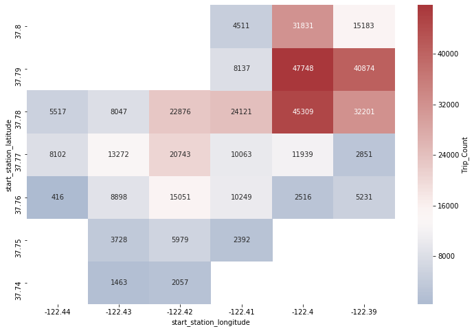

```python
# Plot the heatmap for number of trips started per GPS location of the starting location
plt.figure(figsize=[12,8])

gps_count_start = df_sf.groupby(['start_station_latitude', 'start_station_longitude']).size()
gps_count_start = gps_count_start.reset_index(name = 'trip_count')

# Calculate the count mean by GPS points
count_mean_start = gps_count_start['trip_count'].mean()
gps_count_start = gps_count_start.pivot(index = 'start_station_latitude', columns = 'start_station_longitude',
                            values = 'trip_count')

ax = sb.heatmap(gps_count_start, annot = True, fmt = '.0f',
           cbar_kws = {'label' : 'Trip_Count'}, center = count_mean_start, cmap = 'vlag')

# Prevent top and bottom boxes from being cut off
bottom, top = ax.get_ylim()
ax.set_ylim(bottom + 0.5, top - 0.5)

# reverse y-axis
ax.invert_yaxis()
```

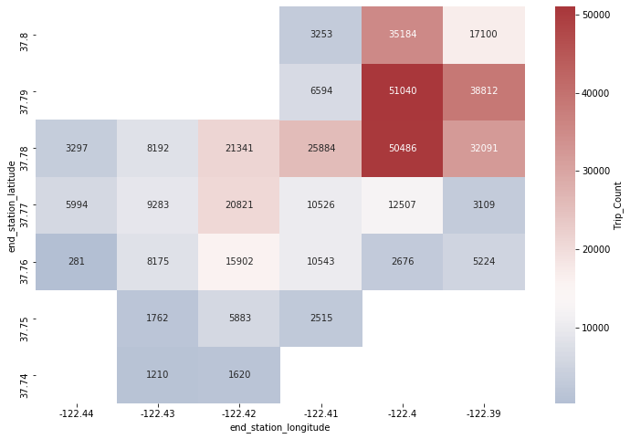

```python
# Plot the heatmap for number of trips ended per GPS location of the ending location
plt.figure(figsize=[12,8])

gps_count_end = df_sf.groupby(['end_station_latitude', 'end_station_longitude']).size()
gps_count_end = gps_count_end.reset_index(name = 'trip_count')

# Calculate the count mean by GPS points
count_mean_end = gps_count_end['trip_count'].mean()
gps_count_end = gps_count_end.pivot(index = 'end_station_latitude', columns = 'end_station_longitude',
                            values = 'trip_count')

ax = sb.heatmap(gps_count_end, annot = True, fmt = '.0f',
           cbar_kws = {'label' : 'Trip_Count'}, center = count_mean_end, cmap = 'vlag')

# Prevent top and bottom boxes from being cut off
bottom, top = ax.get_ylim()
ax.set_ylim(bottom + 0.5, top - 0.5)

# reverse y-axis
ax.invert_yaxis()
```

Let's put these 4 plots as 2 corresponding heatmaps to be able to make meaningful comparisons.

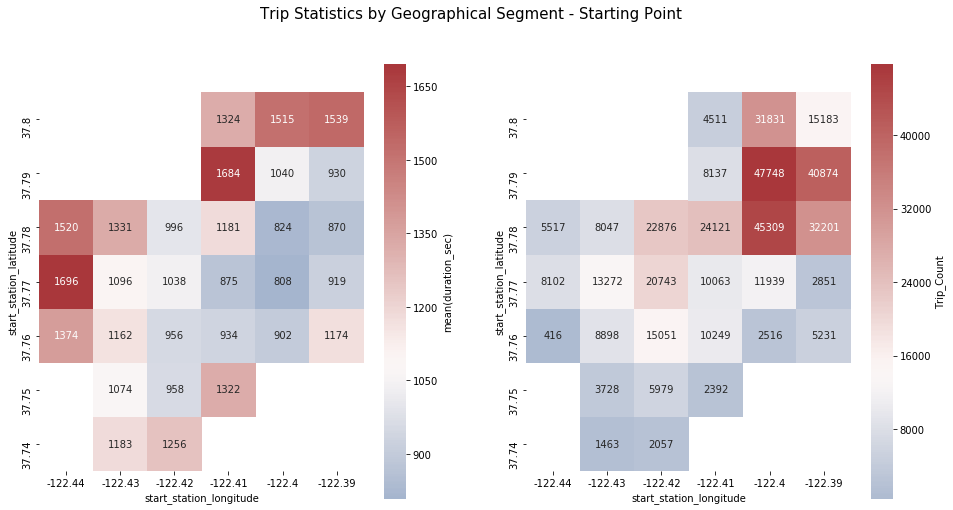

```python
# Plot two starting point heatmaps together for better comparison
plt.figure(figsize=[16,8])


# ----- Plot 1 -----
plt.subplot(1,2,1)
ax1 = sb.heatmap(gps_means_start, annot = True, fmt = '.0f',
           cbar_kws = {'label' : 'mean(duration_sec)'}, center = duration_mean, square = True, cmap = 'vlag')

# Prevent top and bottom boxes from being cut off
bottom, top = ax1.get_ylim()
ax1.set_ylim(bottom + 0.5, top - 0.5)

# reverse y-axis
ax1.invert_yaxis()

# ----- Plot 2 -----
plt.subplot(1,2,2)
ax2 = sb.heatmap(gps_count_start, annot = True, fmt = '.0f',
           cbar_kws = {'label' : 'Trip_Count'}, center = count_mean_start, square = True, cmap = 'vlag')

# Prevent top and bottom boxes from being cut off
bottom, top = ax2.get_ylim()
ax2.set_ylim(bottom + 0.5, top - 0.5)

# reverse y-axis
ax2.invert_yaxis()

# Add the common title
plt.suptitle("Trip Statistics by Geographical Segment - Starting Point", size = 15)
```

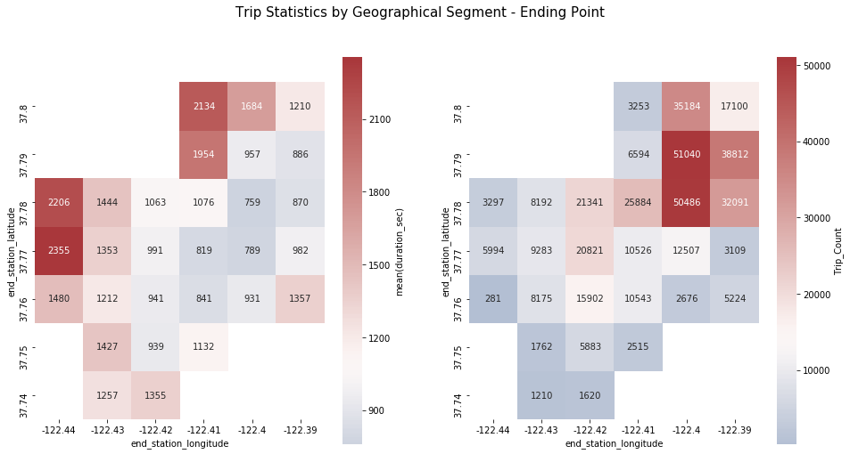

```python
# Plot two ending point heatmaps together for better comparison
plt.figure(figsize=[16,8])

# ----- Plot 1 -----
plt.subplot(1,2,1)
ax1 = sb.heatmap(gps_means_end, annot = True, fmt = '.0f',
           cbar_kws = {'label' : 'mean(duration_sec)'}, center = duration_mean, square = True, cmap = 'vlag')

# Prevent top and bottom boxes from being cut off
bottom, top = ax1.get_ylim()
ax1.set_ylim(bottom + 0.5, top - 0.5)

# reverse y-axis
ax1.invert_yaxis()

# ----- Plot 2 -----
plt.subplot(1,2,2)
ax2 = sb.heatmap(gps_count_end, annot = True, fmt = '.0f',
           cbar_kws = {'label' : 'Trip_Count'}, center = count_mean_end, square = True, cmap = 'vlag')

# Prevent top and bottom boxes from being cut off
bottom, top = ax2.get_ylim()
ax2.set_ylim(bottom + 0.5, top - 0.5)

# reverse y-axis
ax2.invert_yaxis()

# Add the common title
plt.suptitle("Trip Statistics by Geographical Segment - Ending Point", size = 15)
```

### Talk about some of the relationships you observed in this part of the investigation. Were there features that strengthened each other in terms of looking at your feature(s) of interest?

At the beginning of the project, I was reluctant to use latitudes and longitudes because of their assumed uselessness. However, thanks to bulding multivariate models, I make some very important and useful conclusions: it seems that the lion's share of the biking activity happens in the Downtown San Francisco, where bikes are easily taken and out back after some short period of time. The activity on the outskirts are less frequent but trips are longer - meaning that these users mostly have long trips to and from the downtown.

### Were there any interesting or surprising interactions between features?

As I already stated - when I started the project, I did not think to use the geographical data at all, but it seems that we can use it in lots of ways, actually! Personally, it helped me draw the of San Francisco and get interesting observations from there!